# Impact of Covid on Cyclists and Pedestrians in Zurich

Patrice Robin, Patrik Widmer

25.05.2021

# 1 Introduction

Covid19 had a huge impact on our society. It changed the way we interact on a professional and social level. Home offices, lockdowns, and partially closed stores have had a particularly severe impact on urban centers.

In this paper, we will examine the impact of the pandemic on the number of pedestrians and bicycles in different areas of Zurich.

The city of Zurich automatically collects data on pedestrians and bicyclists through counting loops installed in the ground in different areas of the city. We can get a clear view of the impact of Covid19 on our daily lives by looking at the data of pedestrians and cyclists in 2020 and comparing it to the previous year.

# 2 Data

All the data regarding Zurich are pulled from the official website of the city of Zurich *Open Data Stadt Zürich* (2021). The fallowing information are used in this paper:

- Number of pedestrians and bicycles counted in 2020 and 2019
- The location of the counting stations.
- The different *Stadtkreise* and their geodata points.
- The different districts in Zurich with the corresponding geo data points.
- A categorization of different areas based on their usage and building development.

The Covid19 data for Switzerland including the categories *cases, deaths, test, hospitalization, and vaccinations* are based on the research of Roser et al. (2020) and pulled from the *Our World in Data* website. In this paper, we will use the smoothed numbers of newly infected people in Switzerland. We decided to use the smoothed numbers since the newly reported cases are directly linked to the working week of medical staff, laboratories, and the Federal Office of Public Health Switzerland (FOPH). As a result, often fewer cases are reported on the weekend and more cases are listed in the beginning of the working week.

Due to the smoothing of the data, the first recorded Covid19 case in our dataset is from 01.03.2020, while the first recorded case actually appeared on the 25.02.2020.

## 2.1 Preparation

In the initial dataset summarizes the counted pedestrians and cyclists into time frames of 15 minutes. Due to our interest into daily, weekly and monthly changes, we bring the counting data into needed format. Additionally, several adjustment to the data are made for a simpler comparison. The counting stations indicate whether an individual is going into or going out of a center. Since we are interested in the total number of individuals walking or cycling in the area, we summarize them into one number each:

- Total cyclists
- Total Pedestrians

Furthermore, we also summarize those two numbers into one single number containing all the measured pedestrians and cyclists at each location:

- Total People

In a second step, we join the smoothed Covid data to our daily records of cyclists and pedestrians. Before 01.03.2020 there were no covid cases.

Based on the information of the Swiss Tourism Federation (2021) we additionally the two lockdowns in 2020. The first lockdown from March 16th 2020 until Mai 11. 2020. The second lockdown starting in 22. December 2020 and ongoing in the next year.

## 2.2 Counting stations

In the graphic below the counting stations are visualized. The counting stations are not evenly distributed over the twelve districts. The table below shows that district 1 has the most counting stations with a total of 9 and district 7 has no counting stations. We believe that the city of Zurich deliberately selected locations that are highly frequented. Consequently, most counting locations are in the city center or in regional center of Zurich.

A total of 48 different counting location were used to collect the numbers of pedestriand and cyclists during 2019 and 2020.

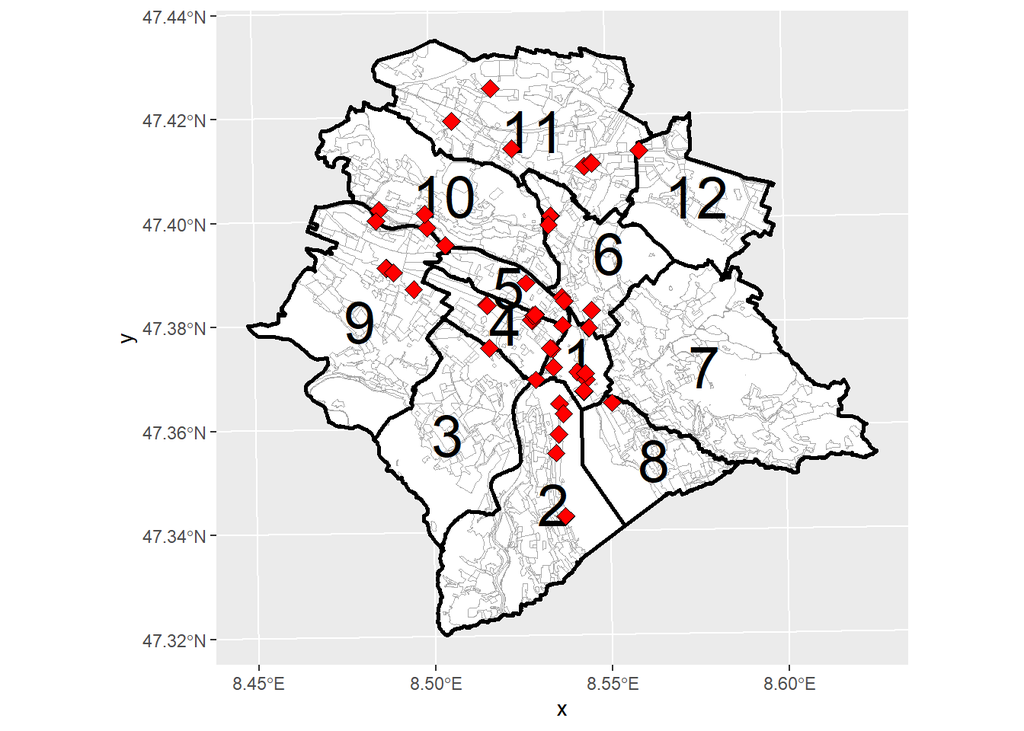

Couting Stations per District

| District | Quantity of Stations |
| --- | --- |
| 1 | 9 |
| 2 | 6 |
| 3 | 1 |
| 4 | 5 |
| 5 | 5 |
| 6 | 5 |
| 7 | 0 |
| 8 | 1 |
| 9 | 5 |
| 10 | 4 |
| 11 | 6 |
| 12 | 1 |
| Total | 48 |

# 3 Analysis

In the main chapter, we look at the counted pedestrians and cyclists counted in 2019 and 2020 within the city of Zurich. We look at the distribution over time, the difference between the 12 Stadtkreise, the difference between the zones the counting stations are positioned in, and lastly the impact of the two lockdowns.

## 3.1 Months

First, we take a closer look at the counted pedestrians and cyclists counted together in 2020 and 2019. A comparison of the monthly data is presented below. The top graph below shows the summarized pedestrians and cyclists for each measurement location for the last two years. The two graphs below show the total of measured people for each month in 2019 and 2020 in a direct comparison.

It is obvious that there were more people on the streets in July, August and September in 2020 than in the previous year. We argue that an explanation are the continuous travel restrictions coming from and going to other countries combined with the eased lockdown within Switzerland.Hence, people spent their holidays at home or simply kept working.

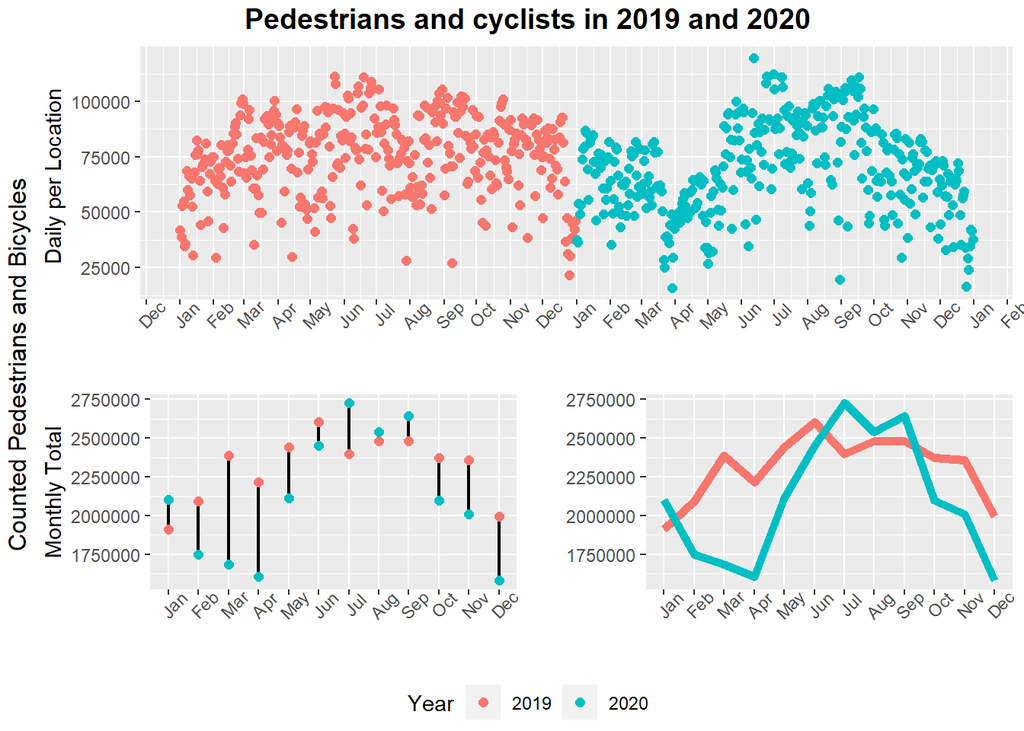

## 3.2 Covid and Lockdown

In the next step we take a look at how the smoothed covid cases and the counted pedestrians and cyclists are plotted against each other. We only include the counting data from March 1st 2020 until December 31st 2020.

By adding a regression line, we can see that there is a negative correlation between the number of cases and the number of counted people. However, the confidence interval of the trend line is not very accurate and an in existing confidence interval with low covid cases.

The clear right skewing of the data is not a surprise, as we had most of the time below 1000 new covid cases per day. The big variety of recorded people in the street are likely due to whether, temperatures, seasonality but also due to the lockdown. The lockdown is a political decision on not directly triggered or linked to the number of recorded cases.

Additionally, we take a look at the counted people during the two lockdowns and non-lockdown period. The lockdown boxplot clearly indicates that there is a difference between the counted people during lockdown and during non-lockdown, with fewer people on the street during the two periods of lockdown.

In a third look at the relationship between the recorded cyclists and pedestrians and the two lockdowns by applying a logistic regression. It becomes clear, that the lockdown has indeed a negative impact on the number of recorded people on the street.

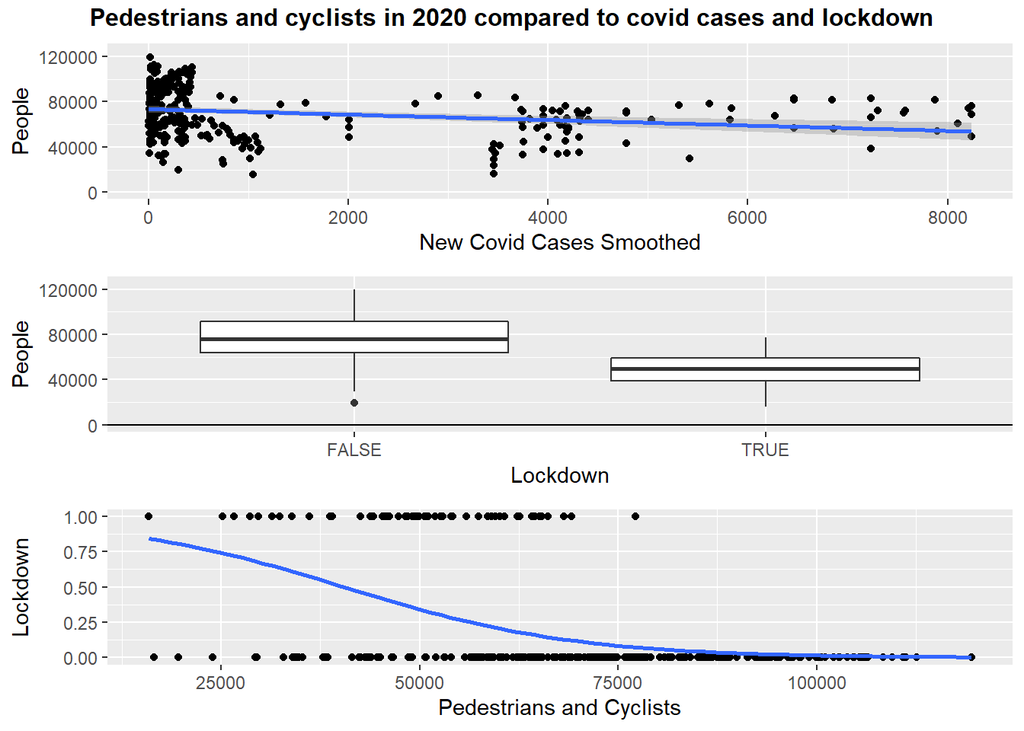

## 3.3 Living and working zones

In the next step we take a look at the different different zones the counting stations are located in. The counting locations are distributed over 11 different zones types. These zones are defined by the state based on their usage and location. We summarized these zones types into five categories to simplify the analysis.

Counting Stations per zone

| typ | zones | Quantity of Stations |
| --- | --- | --- |
| GWS | Recreation | 5 |
| QI | Recreation | 7 |
| WLD | Recreation | 1 |
| W4 | Living | 4 |
| W5 | Living | 6 |
| IG I | Industry | 2 |
| F | Empty/Parking | 6 |
| FP | Empty/Parking | 1 |
| K | Center | 11 |
| Z5 | Center | 3 |
| Z6 | Center | 3 |

Summarized Zones

| zones | Quantity of Stations |
| --- | --- |
| Recreation | 13 |
| Living | 10 |
| Industry | 2 |
| Empty/Parking | 7 |
| Center | 17 |

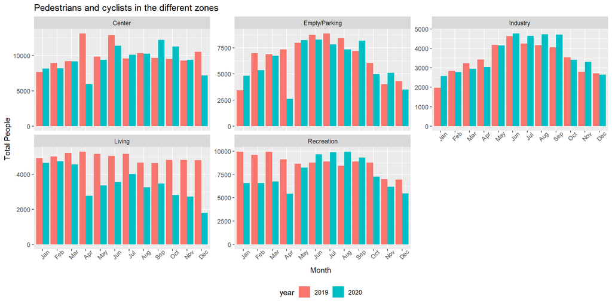

## 3.4 City Districts

In the last analysis part, we take a closer look at the twelve city districts. The twelve plots below show a comparison between 2020 and 2019 in the twelve districts. It seems that we are missing some measurements in district twelve for two months and district seven is missing completly as explained before.

Nevertheless, there are certain differences visible between the districts. District 1 and district 9 are hardest hit by the pandemic and the ongoing shift to home office. District 4, 8, and 12 seem to be more frequently visited by people on foot and bycicle during the pandemic. Our guess is that these districts have several free and open recreational areas. To test this statement, we would need additional information.

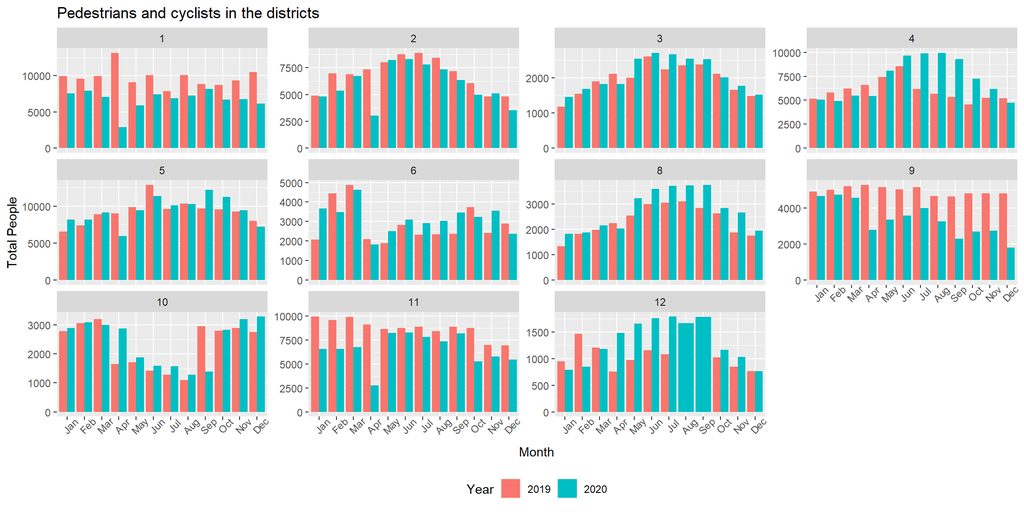

# 4 Video

In a last step, we decided to animate the difference in pedestrians and cyclists counted in 2020 compared to 2019 across time. For each month of 2020, we generate a color coded map. Dark green areas show that fewer pedestrians and bicyclists were counted compared to the previous year.In contrast, dark red areas show that more pedestrians and bicyclists where counted. This plot is combined with a second graph showing the number of COVID cases counted. If you look at zwalks_animation.avi, you can see how the COVID pandemic unfolds and how the number of pedestrians decreases as COVID cases rise.

[video not shown]

# 5 Conclusion

With the mostly visual approach, we could show that the behavior of the people in Zurich changed compared to the previous year. While the impact of the lockdown on the counted people on the streets is no surprise, the clear increase during the summer months was rather unexpected.

The most outstanding part of our visual comparison was the increase of counted cyclists almost through the whole year.

This paper did primarily took a visually based comparison of the number of pedestrians and cyclists in 2019 and 2020 respectively during the two lockdowns in them. For further research, it would be necessary to quantify this identified impact statistically. A longer time series would be necessary to identify and address seasonality and trends in order to identify the impact of covid on the counted people.

# 6 References

## 6.1 Data Sources

Roser, M., Ritchie, H., Ortiz-Ospina, E., & Hasell, J. (2020). Coronavirus Pandemic (COVID-19). Our World in Data. [<https://ourworldindata.org/coronavirus/country/switzerland>](https://ourworldindata.org/coronavirus/country/switzerland) (accessed 20.02.2021).

Stadt Zürich. (2021). Open Data Zürich. https://data.stadt-zuerich.ch/ (accessed 10.02.2021).

Swiss Tourism Federation. (2021). Chronik Coronavirus. [<https://www.stv-fst.ch/de/chronik-coronavirus>](https://www.stv-fst.ch/de/chronik-coronavirus) (accessed 12.02.2021).

Widmer, P., & Robin, P. (2021). Zurich_walks_video. HSLU Bootcamp. https://vimeo.com/516652769 (accessed 25.02.2021)

## Used R-Packages

Allaire, JJ, Yihui Xie, Jonathan McPherson, Javier Luraschi, Kevin Ushey, Aron Atkins, Hadley Wickham, Joe Cheng, Winston Chang, and Richard Iannone. 2020. *Rmarkdown: Dynamic Documents for r*. https://github.com/rstudio/rmarkdown.

Bivand, Roger S., Edzer Pebesma, and Virgilio Gomez-Rubio. 2013. *Applied Spatial Data Analysis with R, Second Edition*. Springer, NY. https://asdar-book.org/.

Bivand, Roger, Tim Keitt, and Barry Rowlingson. 2021. *Rgdal: Bindings for the Geospatial Data Abstraction Library*. https://CRAN.R-project.org/package=rgdal.

Firke, Sam. 2021. *Janitor: Simple Tools for Examining and Cleaning Dirty Data*. https://github.com/sfirke/janitor.

Gohel, David, Hadley Wickham, Lionel Henry, and Jeroen Ooms. 2021. *Gdtools: Utilities for Graphical Rendering*. https://CRAN.R-project.org/package=gdtools.

Henry, Lionel, and Hadley Wickham. 2020. *Purrr: Functional Programming Tools*. https://CRAN.R-project.org/package=purrr.

Hijmans, Robert J. 2020. *Raster: Geographic Data Analysis and Modeling*. https://rspatial.org/raster.

Hlavac, Marek. 2018. *Stargazer: Well-Formatted Regression and Summary Statistics Tables*. https://CRAN.R-project.org/package=stargazer.

Kassambara, Alboukadel. 2020. *Ggpubr: Ggplot2 Based Publication Ready Plots*. https://rpkgs.datanovia.com/ggpubr/.

Lyttle, Ian. 2020. *Vembedr: Embed Video in HTML*. https://github.com/ijlyttle/vembedr.

Müller, Kirill, and Hadley Wickham. 2021. *Tibble: Simple Data Frames*. https://CRAN.R-project.org/package=tibble.

Ooms, Jeroen. 2020. *Av: Working with Audio and Video in r*. https://CRAN.R-project.org/package=av.

Pebesma, Edzer. 2018. “Simple Features for R: Standardized Support for Spatial Vector Data.” *The R Journal* 10 (1): 439–46. https://doi.org/10.32614/RJ-2018-009.

———. 2021. *Sf: Simple Features for r*. https://CRAN.R-project.org/package=sf.

Pebesma, Edzer J., and Roger S. Bivand. 2005. “Classes and Methods for Spatial Data in R.” *R News* 5 (2): 9–13. https://CRAN.R-project.org/doc/Rnews/.

Pebesma, Edzer, and Roger Bivand. 2020. *Sp: Classes and Methods for Spatial Data*. https://CRAN.R-project.org/package=sp.

Perpinan Lamigueiro, Oscar, and Robert Hijmans. 2020. *rasterVis: Visualization Methods for Raster Data*. https://oscarperpinan.github.io/rastervis/.

Sarkar, Deepayan. 2008. *Lattice: Multivariate Data Visualization with r*. New York: Springer. http://lmdvr.r-forge.r-project.org.

———. 2020. *Lattice: Trellis Graphics for r*. http://lattice.r-forge.r-project.org/.

Sarkar, Deepayan, and Felix Andrews. 2019. *latticeExtra: Extra Graphical Utilities Based on Lattice*. http://latticeextra.r-forge.r-project.org/.

Wickham, Hadley. 2016. *Ggplot2: Elegant Graphics for Data Analysis*. Springer-Verlag New York. https://ggplot2.tidyverse.org.

———. 2019a. *Stringr: Simple, Consistent Wrappers for Common String Operations*. https://CRAN.R-project.org/package=stringr.

———. 2019b. *Tidyverse: Easily Install and Load the Tidyverse*. https://CRAN.R-project.org/package=tidyverse.

———. 2020. *Tidyr: Tidy Messy Data*. https://CRAN.R-project.org/package=tidyr.

———. 2021. *Forcats: Tools for Working with Categorical Variables (Factors)*. https://CRAN.R-project.org/package=forcats.

Wickham, Hadley, Mara Averick, Jennifer Bryan, Winston Chang, Lucy D’Agostino McGowan, Romain François, Garrett Grolemund, et al. 2019. “Welcome to the tidyverse.” *Journal of Open Source Software* 4 (43): 1686. https://doi.org/10.21105/joss.01686.

Wickham, Hadley, and Jennifer Bryan. 2021. *Usethis: Automate Package and Project Setup*. https://CRAN.R-project.org/package=usethis.

Wickham, Hadley, Winston Chang, Lionel Henry, Thomas Lin Pedersen, Kohske Takahashi, Claus Wilke, Kara Woo, Hiroaki Yutani, and Dewey Dunnington. 2020. *Ggplot2: Create Elegant Data Visualisations Using the Grammar of Graphics*. https://CRAN.R-project.org/package=ggplot2.

Wickham, Hadley, Romain François, Lionel Henry, and Kirill Müller. 2021. *Dplyr: A Grammar of Data Manipulation*. https://CRAN.R-project.org/package=dplyr.

Wickham, Hadley, and Jim Hester. 2020. *Readr: Read Rectangular Text Data*. https://CRAN.R-project.org/package=readr.

Wickham, Hadley, Jim Hester, and Winston Chang. 2020. *Devtools: Tools to Make Developing r Packages Easier*. https://CRAN.R-project.org/package=devtools.

Wickham, Hadley, and Dana Seidel. 2020. *Scales: Scale Functions for Visualization*. https://CRAN.R-project.org/package=scales.

Xie, Yihui, J. J. Allaire, and Garrett Grolemund. 2018. *R Markdown: The Definitive Guide*. Boca Raton, Florida: Chapman; Hall/CRC. https://bookdown.org/yihui/rmarkdown.

Xie, Yihui, Christophe Dervieux, and Emily Riederer. 2020. *R Markdown Cookbook*. Boca Raton, Florida: Chapman; Hall/CRC. https://bookdown.org/yihui/rmarkdown-cookbook.

Zhu, Hao. 2021. *kableExtra: Construct Complex Table with Kable and Pipe Syntax*. https://CRAN.R-project.org/package=kableExtra.